# project

## Variable 183

```r
head(data$x183)
```

```
## [1] 0 0 0 0 0 0
```

```r
## Summary of the data
summary(data$x183)
```

```
##    Min. 1st Qu.  Median    Mean 3rd Qu.    Max.
##  0.0000  0.0000  0.0000  0.1989  0.0000 19.0000
```

##Here we found that mean and median are not pretty close and we can say that the distribution of the variable is not approximately normal

##Missing Values: ##There are no missing values

##Description of the data

```r
#install.packages("psych")

describe(data$x183)
```

```
##    vars     n mean   sd median trimmed mad min max range skew kurtosis se
## X1    1 1e+05  0.2 0.63      0    0.05   0   0  19    19 6.25    73.53  0
```

## Here the kurtosis is very high positive hence there is large data in tail

```r
table(data$x183)
```

```
##
##     0     1     2     3     4     5     6     7     8     9    10    11
## 86326 10016  2387   705   276   138    62    30    21    11     7     5
##    12    13    14    15    16    19
##     5     3     4     1     2     1
```

```r
str(data$x183)
```

```
##  int [1:100000] 0 0 0 0 0 0 0 0 0 1 ...
```

```r
class(data$x183)
```

```
## [1] "integer"
```

## here the all values in integer

```r
##Total number of values excluding NA
NROW(data[which(data$x183<=2),])
```

```
## [1] 98729
```

##i.e;., 98%

```r
NROW(data[which(data$x183<=5),])
```

```
## [1] 99848
```

##i.e;.,99%

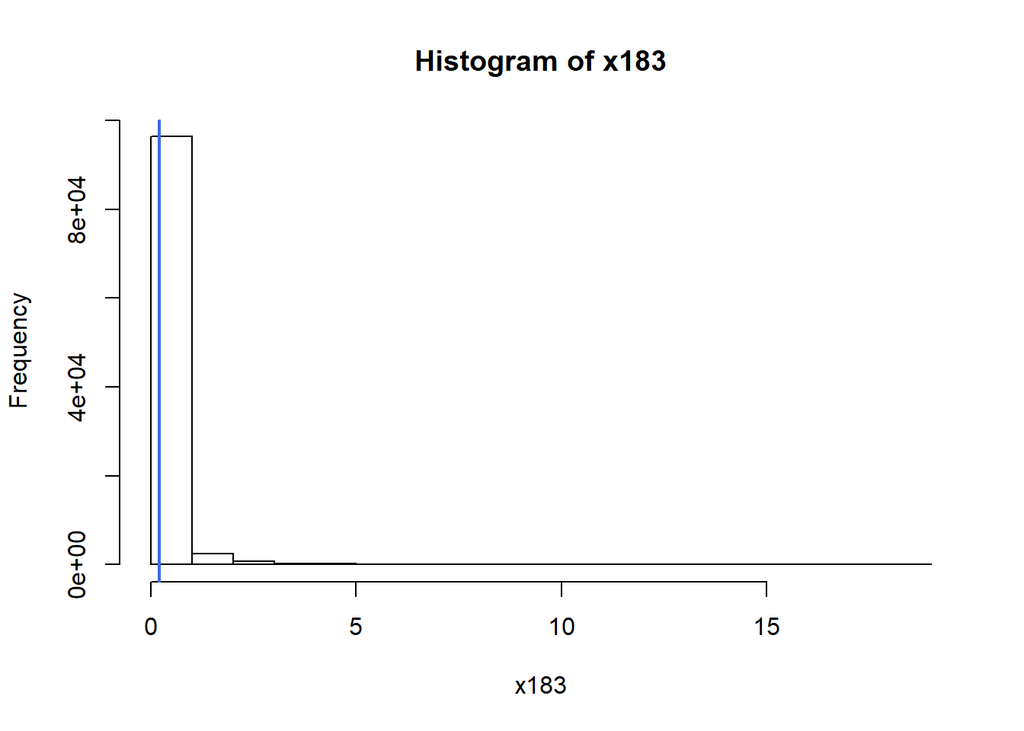

```r
##Now visualize the statistics
##Histogram

hist(data$x183,
    main = "Histogram of x183",
    xlab = "x183")
abline(v =mean(data$x183, na.rm = TRUE),col = "royalblue",
lwd = 2)
```

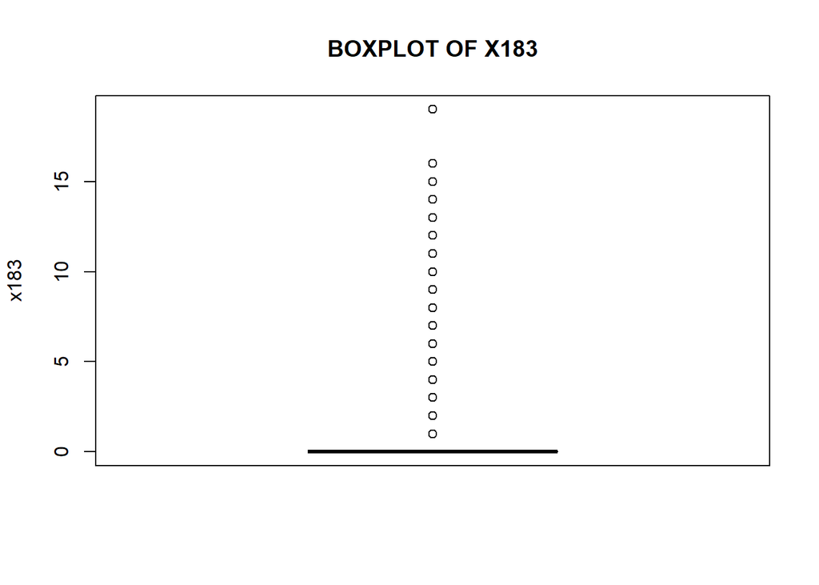

```r
##Boxplot
boxplot(data$x183,
       main = toupper("Boxplot of x183"),
       ylab = "x183",
       col = "blue")
```

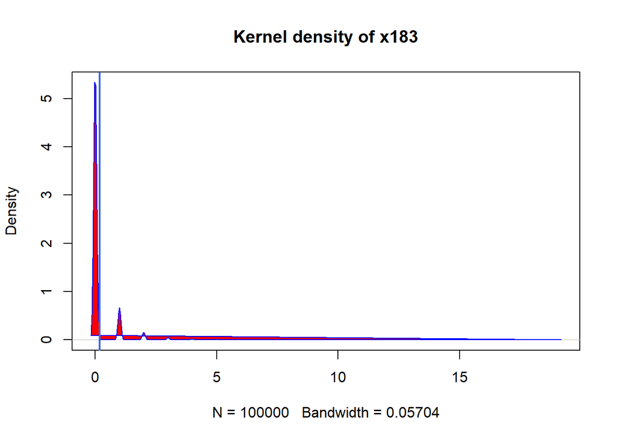

```r
##Density Plot
d <- density(data$x183, na.rm = TRUE)
plot(d, main = "Kernel density of x183")
polygon(d, col = "red", border = "blue")
abline(v =mean(data$x183, na.rm = TRUE),col = "royalblue",
lwd = 2)
```

## There is positive skewness in the data. There are no missing values. This variable have descrete values.

## Variable 184

```r
head(data$x184)
```

```
## [1] 0 0 0 0 0 0
```

```r
## Summary of the data
summary(data$x184)
```

```
##    Min. 1st Qu.  Median    Mean 3rd Qu.    Max.
##  0.0000  0.0000  0.0000  0.1689  0.0000 32.0000
```

##Here we found that mean and median are not pretty close and we can say that the distribution of the variable is not approximately normal

##Missing Values: ##There are no missing values

##Description of the data

```r
#install.packages("psych")

describe(data$x184)
```

```
##    vars     n mean   sd median trimmed mad min max range  skew kurtosis se
## X1    1 1e+05 0.17 0.78      0       0   0   0  32    32 11.45    210.8  0
```

## Here the kurtosis is very high positive hence there is large data in tail

```r
table(data$x184)
```

```
##
##     0     1     2     3     4     5     6     7     8     9    10    11
## 90145  6987  1595   551   234   117    77    61    55    40    31    25
##    12    13    14    15    16    17    18    19    20    24    27    28
##    14    10    19    10     5     9     5     3     3     1     1     1
##    32
##     1
```

```r
str(data$x184)
```

```
##  int [1:100000] 0 0 0 0 0 0 0 0 0 0 ...
```

```r
class(data$x184)
```

```
## [1] "integer"
```

## here the all values in integer

```r
##Total number of values excluding NA
NROW(data[which(data$x184<=2),])
```

```
## [1] 98727
```

##i.e;., 98%

```r
NROW(data[which(data$x184<=5),])
```

```
## [1] 99629
```

##i.e;.,99%

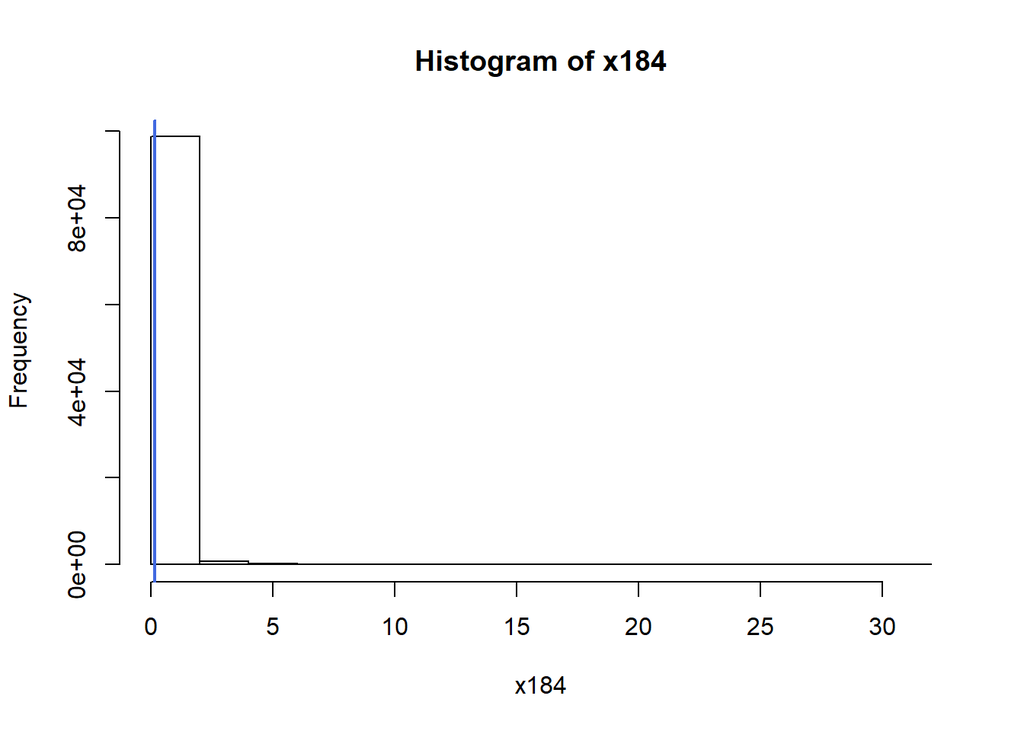

```r
##Now visualize the statistics
##Histogram

hist(data$x184,
    main = "Histogram of x184",
    xlab = "x184")
abline(v =mean(data$x184, na.rm = TRUE),col = "royalblue",
lwd = 2)
```

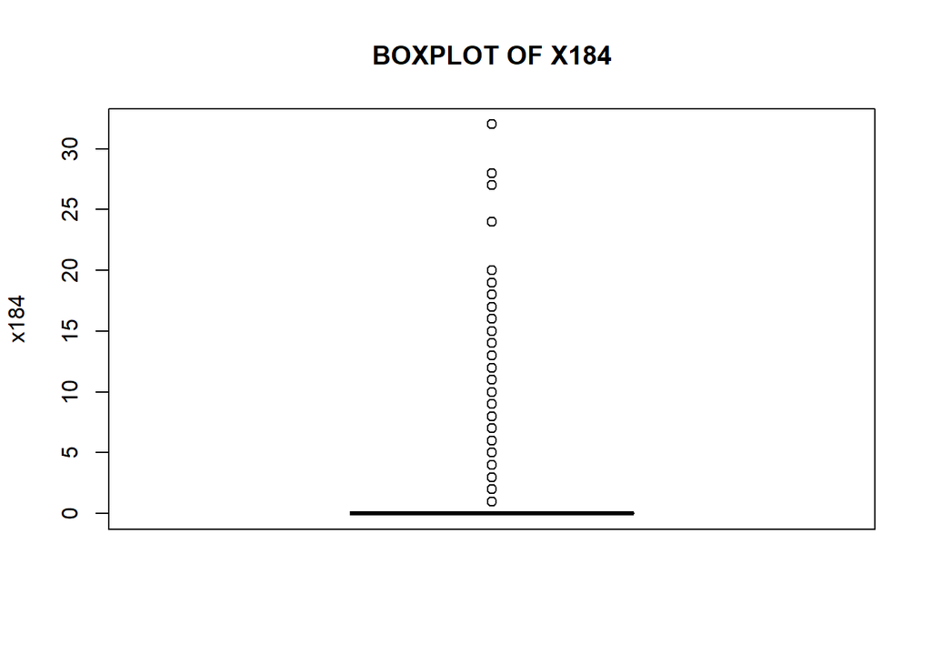

```r
##Boxplot
boxplot(data$x184,
       main = toupper("Boxplot of x184"),
       ylab = "x184",
       col = "blue")
```

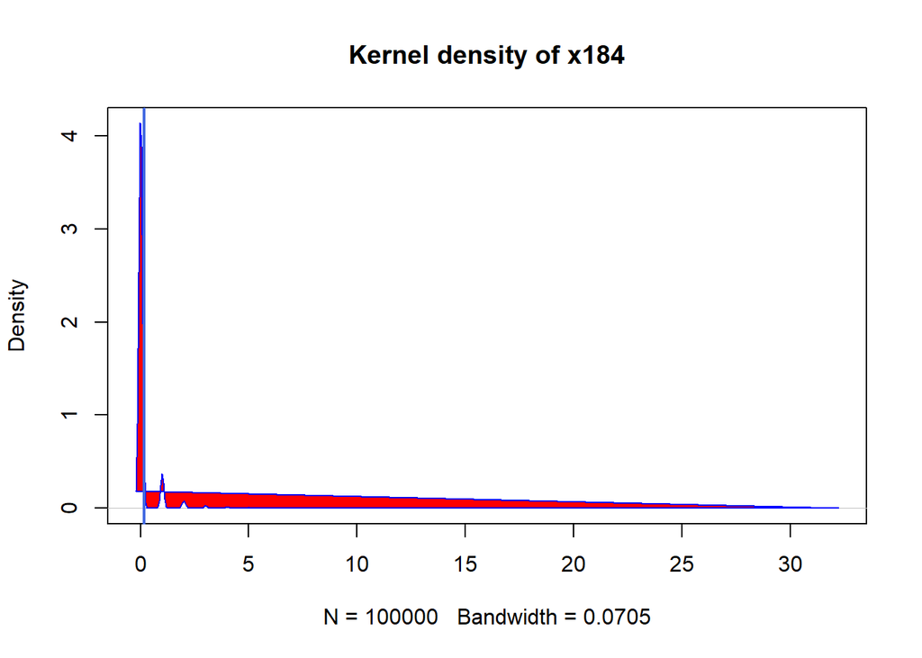

```r
##Density Plot
d <- density(data$x184, na.rm = TRUE)
plot(d, main = "Kernel density of x184")
polygon(d, col = "red", border = "blue")
abline(v =mean(data$x184, na.rm = TRUE),col = "royalblue",
lwd = 2)
```

## There is positive skewness in the data. There are no missing values. This variable have descrete values.

## Variable 185

```r
head(data$x185)
```

```
## [1] 0 0 0 1 0 0
```

```r
## Summary of the data
summary(data$x185)
```

```
##    Min. 1st Qu.  Median    Mean 3rd Qu.    Max.
##  0.0000  0.0000  0.0000  0.6392  0.0000 53.0000
```

##Here we found that mean and median are not pretty close and we can say that the distribution of the variable is not approximately normal

##Missing Values: ##There are no missing values

##Description of the data

```r
#install.packages("psych")

describe(data$x185)
```

```
##    vars     n mean   sd median trimmed mad min max range skew kurtosis
## X1    1 1e+05 0.64 1.95      0    0.18   0   0  53    53  6.1    56.63
##      se
## X1 0.01
```

## Here the kurtosis is very high positive hence there is large data in tail

```r
table(data$x185)
```

```
##
##     0     1     2     3     4     5     6     7     8     9    10    11
## 77170 10877  4868  2154  1425   786   593   383   379   245   221   166
##    12    13    14    15    16    17    18    19    20    21    22    23
##   149   109    99    70    64    45    49    34    21    24    16    13
##    24    25    26    27    28    29    31    32    33    34    35    36
##     5     3     8     7     5     1     2     2     1     1     1     1
##    40    52    53
##     1     1     1
```

```r
str(data$x185)
```

```
##  int [1:100000] 0 0 0 1 0 0 0 0 0 0 ...
```

```r
class(data$x185)
```

```
## [1] "integer"
```

## here the all values in integer

```r
##Total number of values excluding NA
NROW(data[which(data$x185<=2),])
```

```
## [1] 92915
```

##i.e;., 92%

```r
NROW(data[which(data$x185<=5),])
```

```
## [1] 97280
```

##i.e;.,97%

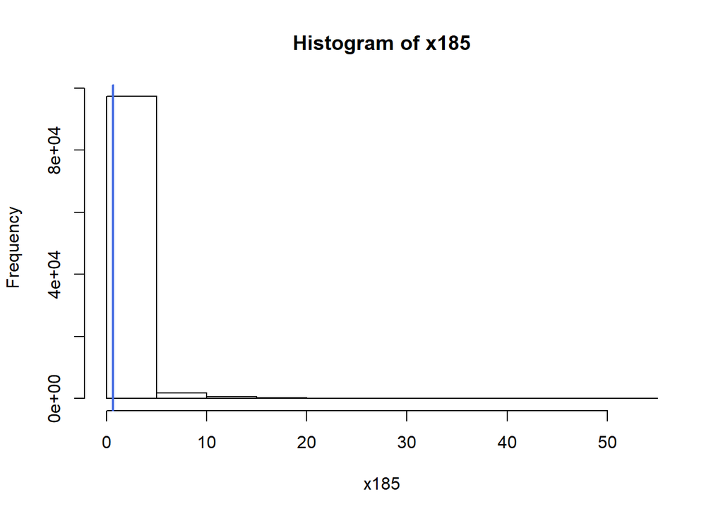

```r
##Now visualize the statistics
##Histogram

hist(data$x185,
    main = "Histogram of x185",
    xlab = "x185")
abline(v =mean(data$x185, na.rm = TRUE),col = "royalblue",
lwd = 2)
```

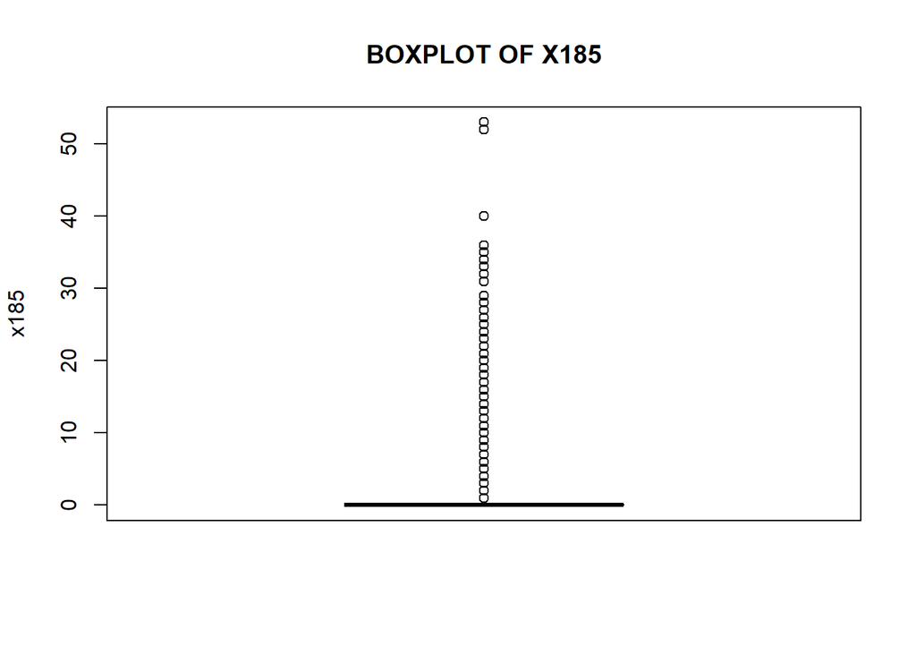

```r
##Boxplot
boxplot(data$x185,
       main = toupper("Boxplot of x185"),
       ylab = "x185",
       col = "blue")
```

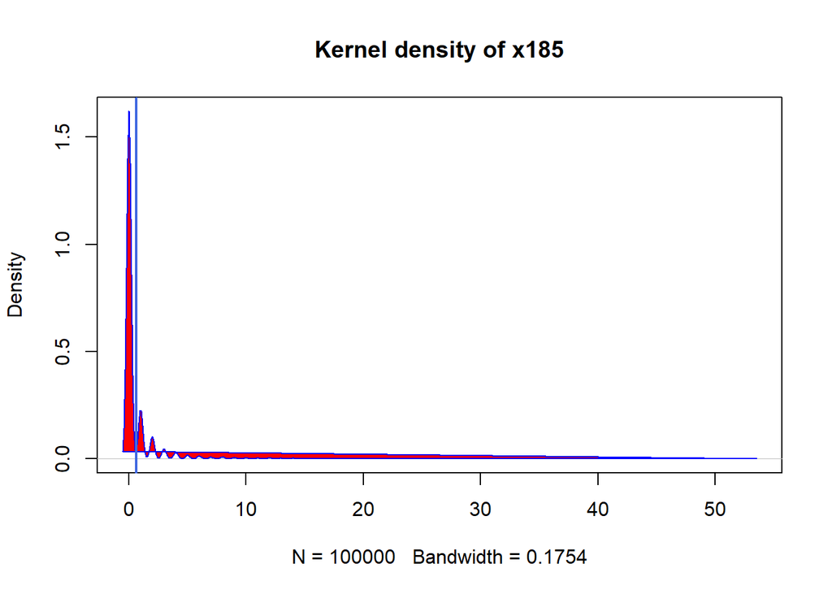

```r
##Density Plot
d <- density(data$x185, na.rm = TRUE)
plot(d, main = "Kernel density of x185")
polygon(d, col = "red", border = "blue")
abline(v =mean(data$x185, na.rm = TRUE),col = "royalblue",
lwd = 2)
```

## Obervation ## From the above graphs and stats i observed that 92% are below 2 and 97% are below 5

## There is positive skewness in the data. There are no missing values. This variable have descrete values.

## Variable 186

```r
head(data$x186)
```

```
## [1]  0  0  0  9  2 10
```

```r
## Summary of the data
summary(data$x186)
```

```
##    Min. 1st Qu.  Median    Mean 3rd Qu.    Max.
##   0.000   0.000   0.000   7.801   6.000 818.000
```

##Here we found that mean and median are not pretty close and we can say that the distribution of the variable is not approximately normal

##Missing Values: ##There are no missing values

##Description of the data

```r
#install.packages("psych")

describe(data$x186)
```

```
##    vars     n mean    sd median trimmed mad min max range skew kurtosis
## X1    1 1e+05  7.8 20.04      0    3.08   0   0 818   818 6.36    82.89
##      se
## X1 0.06
```

## Here the kurtosis is very high positive hence there is large data in tail

```r
table(data$x186)
```

```
##
##     0     1     2     3     4     5     6     7     8     9    10    11
## 56907  6174  3764  2884  2388  1807  1624  1382  1251  1435  1214   954
##    12    13    14    15    16    17    18    19    20    21    22    23
##   973   805   775   661   702   546   819   514   706   473   499   397
##    24    25    26    27    28    29    30    31    32    33    34    35
##   446   363   388   410   400   267   406   255   319   272   280   219
##    36    37    38    39    40    41    42    43    44    45    46    47
##   277   218   242   249   264   186   195   160   181   181   152   137
##    48    49    50    51    52    53    54    55    56    57    58    59
##   193   108   122   109   114    84   131    91    86    66    77    81
##    60    61    62    63    64    65    66    67    68    69    70    71
##   105    91    96    76    83    60    72    60    59    36    61    45
##    72    73    74    75    76    77    78    79    80    81    82    83
##    79    36    47    54    37    29    30    32    48    33    37    29
```

[output cut: 32 more lines]

```r
str(data$x186)
```

```
##  int [1:100000] 0 0 0 9 2 10 0 3 0 19 ...
```

```r
class(data$x186)
```

```
## [1] "integer"
```

## here the all values in integer

```r
##Total number of values excluding NA
NROW(data[which(data$x186<=2),])
```

```
## [1] 66845
```

##i.e;., 66%

```r
NROW(data[which(data$x186<=5),])
```

```
## [1] 73924
```

##i.e;.,73%

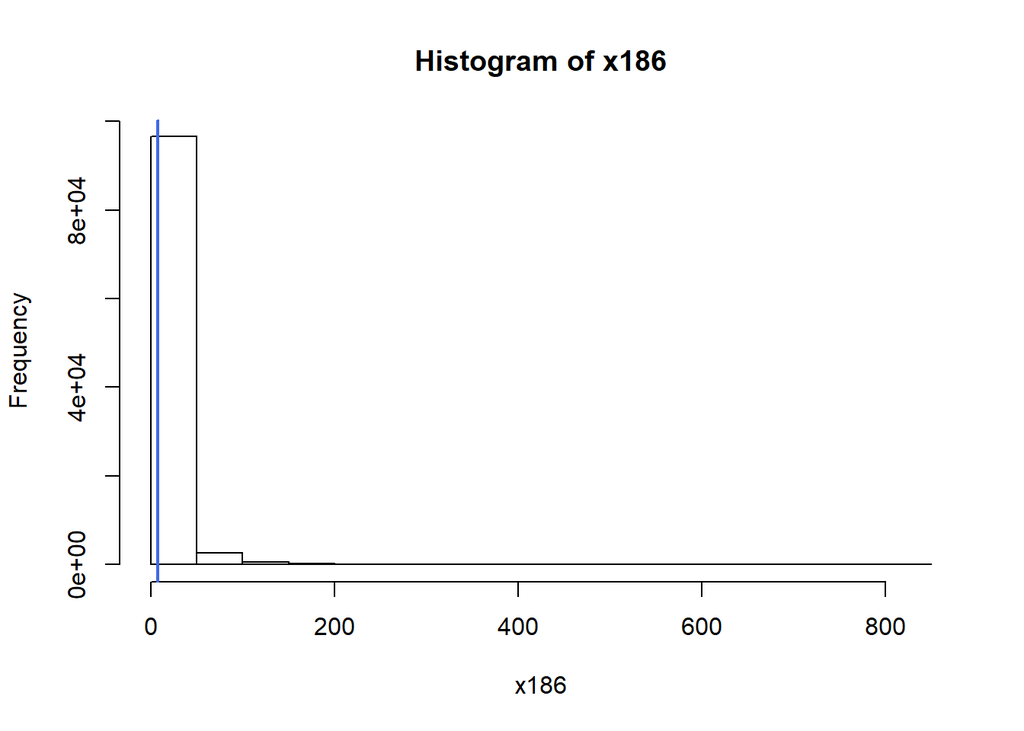

```r
##Now visualize the statistics
##Histogram

hist(data$x186,
    main = "Histogram of x186",
    xlab = "x186")
abline(v =mean(data$x186, na.rm = TRUE),col = "royalblue",
lwd = 2)
```

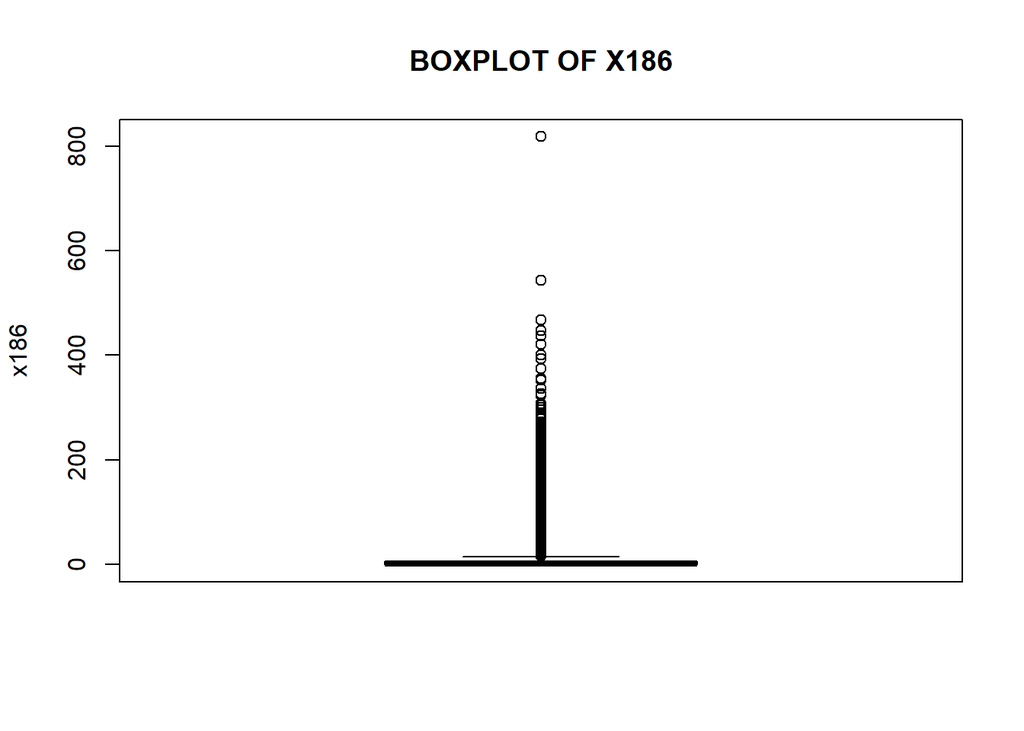

```r
##Boxplot
boxplot(data$x186,
       main = toupper("Boxplot of x186"),
       ylab = "x186",
       col = "blue")
```

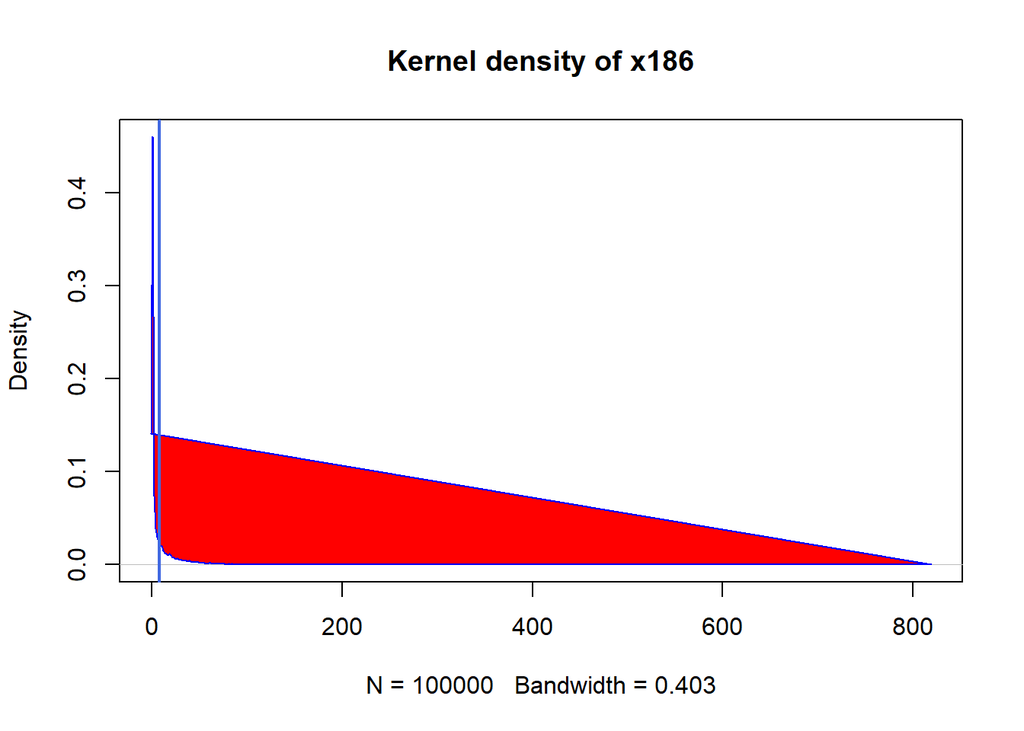

```r
##Density Plot
d <- density(data$x186, na.rm = TRUE)
plot(d, main = "Kernel density of x186")
polygon(d, col = "red", border = "blue")
abline(v =mean(data$x186, na.rm = TRUE),col = "royalblue",
lwd = 2)
```

## Obervation ## From the above graphs and stats i observed that 66% are below 2 and 73% are below 5

## There is positive skewness in the data. There are no missing values. This variable have descrete values.

## Variable 187

```r
head(data$x187)
```

```
## [1] 0 0 0 3 0 0
```

```r
## Summary of the data
summary(data$x187)
```

```
##    Min. 1st Qu.  Median    Mean 3rd Qu.    Max.
##  0.0000  0.0000  0.0000  0.2695  0.0000 31.0000
```

##Here we found that mean and median are not pretty close and we can say that the distribution of the variable is not approximately normal

##Missing Values: ##There are no missing values

##Description of the data

```r
#install.packages("psych")

describe(data$x187)
```

```
##    vars     n mean   sd median trimmed mad min max range skew kurtosis se
## X1    1 1e+05 0.27 0.99      0    0.03   0   0  31    31 7.26    89.72  0
```

## Here the kurtosis is very high positive hence there is large data in tail

```r
table(data$x187)
```

```
##
##     0     1     2     3     4     5     6     7     8     9    10    11
## 87321  6771  2675  1426   774   354   228   127    98    73    46    31
##    12    13    14    15    16    17    18    19    20    22    24    25
##    16    14     8    12     6     4     4     2     1     4     1     2
##    29    31
##     1     1
```

```r
str(data$x187)
```

```
##  int [1:100000] 0 0 0 3 0 0 0 0 0 0 ...
```

```r
class(data$x187)
```

```
## [1] "integer"
```

## here the all values in integer

```r
##Total number of values excluding NA
NROW(data[which(data$x187<=2),])
```

```
## [1] 96767
```

##i.e;., 96%

```r
NROW(data[which(data$x187<=5),])
```

```
## [1] 99321
```

##i.e;.,99%

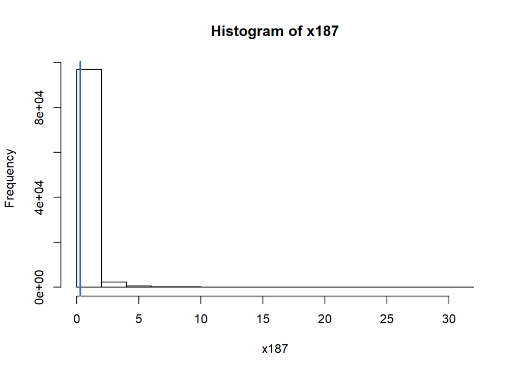

```r
##Now visualize the statistics
##Histogram

hist(data$x187,
    main = "Histogram of x187",
    xlab = "x187")
abline(v =mean(data$x187, na.rm = TRUE),col = "royalblue",
lwd = 2)
```

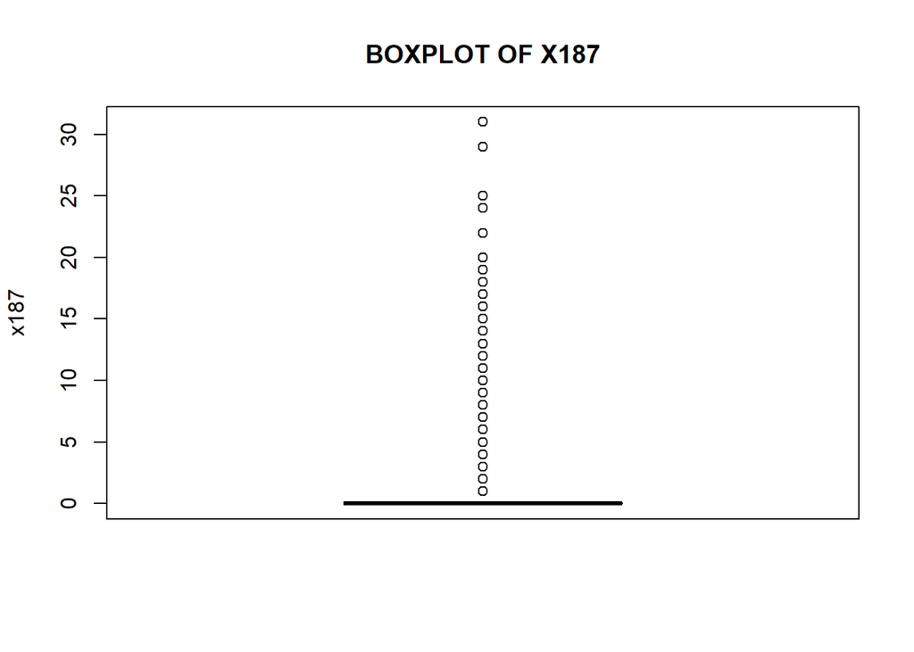

```r
##Boxplot
boxplot(data$x187,
       main = toupper("Boxplot of x187"),
       ylab = "x187",
       col = "blue")
```

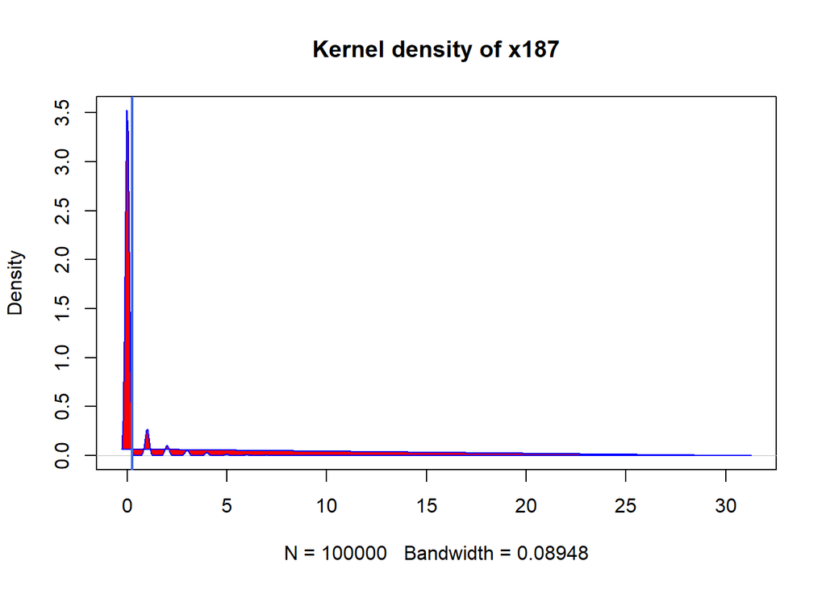

```r
##Density Plot
d <- density(data$x187, na.rm = TRUE)
plot(d, main = "Kernel density of x187")
polygon(d, col = "red", border = "blue")
abline(v =mean(data$x187, na.rm = TRUE),col = "royalblue",
lwd = 2)
```

## There is positive skewness in the data. There are no missing values. This variable have descrete values.

## Variable 188

```r
head(data$x188)
```

```
## [1] 0 0 0 6 1 0
```

```r
## Summary of the data
summary(data$x188)
```

```
##    Min. 1st Qu.  Median    Mean 3rd Qu.    Max.
##  0.0000  0.0000  0.0000  0.4899  0.0000 52.0000
```

##Here we found that mean and median are not pretty close and we can say that the distribution of the variable is not approximately normal

##Missing Values: ##There are no missing values

##Description of the data

```r
#install.packages("psych")

describe(data$x188)
```

```
##    vars     n mean   sd median trimmed mad min max range skew kurtosis
## X1    1 1e+05 0.49 1.59      0    0.09   0   0  52    52 6.17    65.39
##      se
## X1 0.01
```

## Here the kurtosis is very high positive hence there is large data in tail

```r
table(data$x188)
```

```
##
##     0     1     2     3     4     5     6     7     8     9    10    11
## 82467  7796  3433  2014  1312   829   598   402   296   246   200   102
##    12    13    14    15    16    17    18    19    20    21    22    23
##    72    51    42    37    18    22    16     7     8     4     5     2
##    24    25    28    29    30    31    32    34    35    36    52
##     5     3     1     2     1     1     2     1     1     3     1
```

```r
str(data$x188)
```

```
##  int [1:100000] 0 0 0 6 1 0 0 1 0 4 ...
```

```r
class(data$x188)
```

```
## [1] "integer"
```

## here the all values in integer

```r
##Total number of values excluding NA
NROW(data[which(data$x188<=2),])
```

```
## [1] 93696
```

##i.e;., 93%

```r
NROW(data[which(data$x188<=5),])
```

```
## [1] 97851
```

##i.e;.,97%

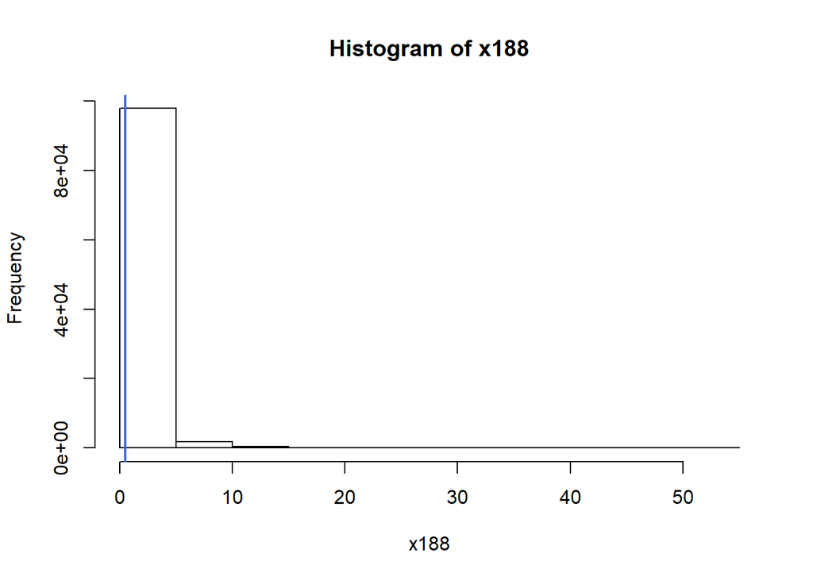

```r
##Now visualize the statistics
##Histogram

hist(data$x188,
    main = "Histogram of x188",
    xlab = "x188")
abline(v =mean(data$x188, na.rm = TRUE),col = "royalblue",
lwd = 2)
```

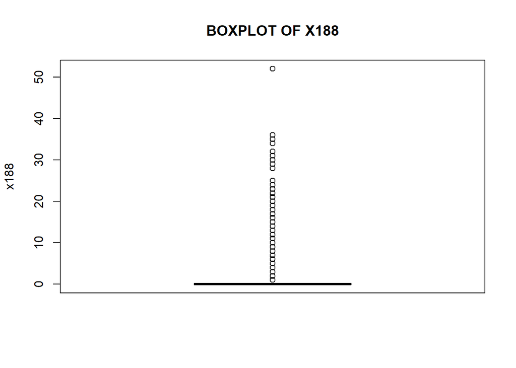

```r
##Boxplot
boxplot(data$x188,
       main = toupper("Boxplot of x188"),
       ylab = "x188",
       col = "blue")
```

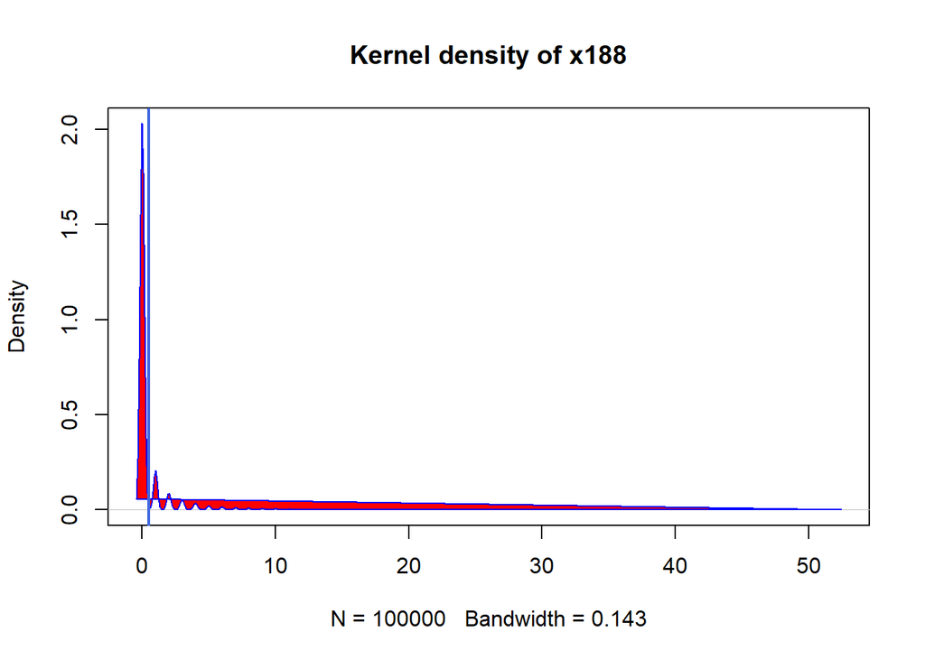

```r
##Density Plot
d <- density(data$x188, na.rm = TRUE)
plot(d, main = "Kernel density of x188")
polygon(d, col = "red", border = "blue")
abline(v =mean(data$x188, na.rm = TRUE),col = "royalblue",
lwd = 2)
```

## Obervation ## From the above graphs and stats i observed that 93% are below 2 and 97% are below 5

## There is positive skewness in the data. There are no missing values. This variable have descrete values.

## Variable 189

```r
head(data$x189)
```

```
## [1] 0 0 0 7 2 0
```

```r
## Summary of the data
summary(data$x189)
```

```
##    Min. 1st Qu.  Median    Mean 3rd Qu.    Max.
##  0.0000  0.0000  0.0000  0.8439  0.0000 68.0000
```

##Here we found that mean and median are not pretty close and we can say that the distribution of the variable is not approximately normal

##Missing Values: ##There are no missing values

##Description of the data

```r
#install.packages("psych")

describe(data$x189)
```

```
##    vars     n mean   sd median trimmed mad min max range skew kurtosis
## X1    1 1e+05 0.84 2.52      0    0.21   0   0  68    68 5.56    48.11
##      se
## X1 0.01
```

## Here the kurtosis is very high positive hence there is large data in tail

```r
table(data$x189)
```

```
##
##     0     1     2     3     4     5     6     7     8     9    10    11
## 77086  8884  4056  2468  1690  1249   908   720   573   464   373   264
##    12    13    14    15    16    17    18    19    20    21    22    23
##   212   187   146   130   124    92    65    71    45    25    42    19
##    24    25    26    27    28    29    30    31    32    33    34    35
##    18     9     8     9    12     5     7     5     3     5     4     2
##    36    38    39    40    41    42    44    45    52    53    68
##     5     2     1     1     2     2     1     2     2     1     1
```

```r
str(data$x189)
```

```
##  int [1:100000] 0 0 0 7 2 0 0 1 0 4 ...
```

```r
class(data$x189)
```

```
## [1] "integer"
```

## here the all values in integer

```r
##Total number of values excluding NA
NROW(data[which(data$x189<=2),])
```

```
## [1] 90026
```

##i.e;., 90%

```r
NROW(data[which(data$x189<=5),])
```

```
## [1] 95433
```

##i.e;.,95%

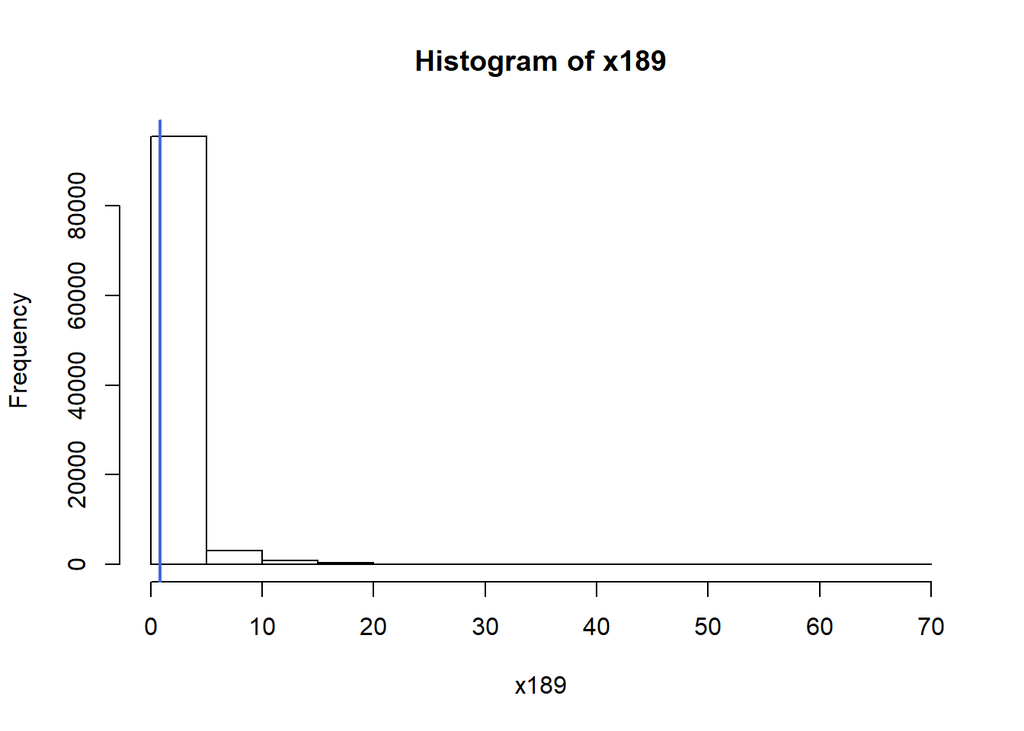

```r
##Now visualize the statistics
##Histogram

hist(data$x189,
    main = "Histogram of x189",
    xlab = "x189")
abline(v =mean(data$x189, na.rm = TRUE),col = "royalblue",
lwd = 2)
```

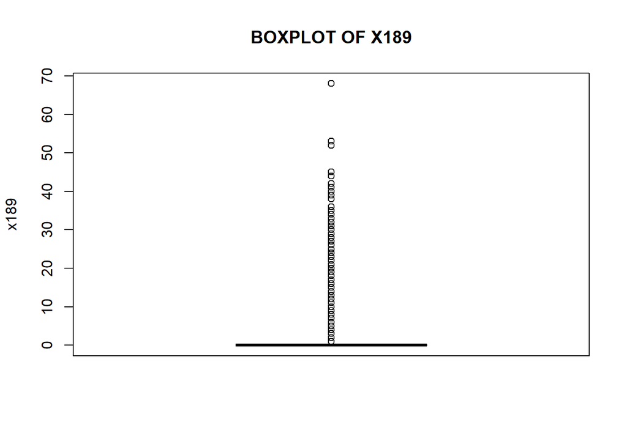

```r
##Boxplot
boxplot(data$x189,
       main = toupper("Boxplot of x189"),
       ylab = "x189",
       col = "blue")
```

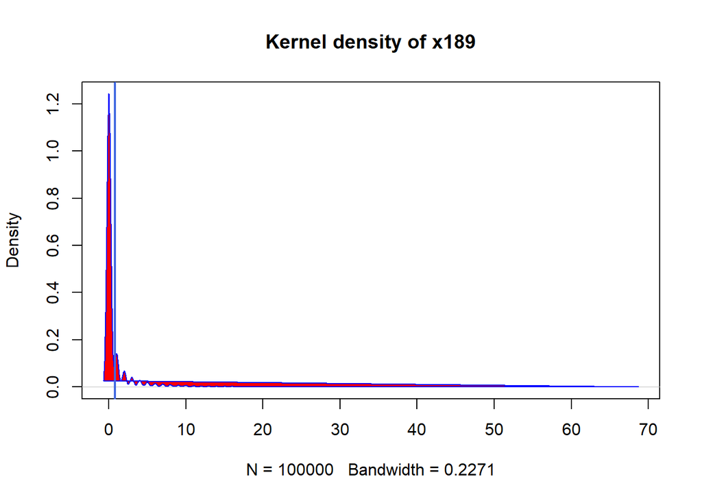

```r
##Density Plot
d <- density(data$x189, na.rm = TRUE)
plot(d, main = "Kernel density of x189")
polygon(d, col = "red", border = "blue")
abline(v =mean(data$x189, na.rm = TRUE),col = "royalblue",
lwd = 2)
```

## Obervation ## From the above graphs and stats i observed that 90% are below 2 and 95% are below 5

## There is positive skewness in the data. There are no missing values. This variable have descrete values.

## Variable 190

```r
head(data$x190)
```

```
## [1] 0 0 0 7 2 3
```

```r
## Summary of the data
summary(data$x190)
```

```
##    Min. 1st Qu.  Median    Mean 3rd Qu.    Max.
##   0.000   0.000   0.000   1.152   1.000  70.000
```

##Here we found that mean and median are not pretty close and we can say that the distribution of the variable is not approximately normal

##Missing Values: ##There are no missing values

##Description of the data

```r
#install.packages("psych")

describe(data$x190)
```

```
##    vars     n mean   sd median trimmed mad min max range skew kurtosis
## X1    1 1e+05 1.15 3.32      0    0.33   0   0  70    70 5.42    43.58
##      se
## X1 0.01
```

## Here the kurtosis is very high positive hence there is large data in tail

```r
table(data$x190)
```

```
##
##     0     1     2     3     4     5     6     7     8     9    10    11
## 73304  9612  4548  2848  1909  1414  1090   886   738   551   476   367
##    12    13    14    15    16    17    18    19    20    21    22    23
##   353   268   222   230   170   132   123    99    91    86    67    53
##    24    25    26    27    28    29    30    31    32    33    34    35
##    56    36    36    29    20    25    13    23    18    17    15     8
##    36    37    38    39    40    41    42    43    44    45    46    47
##     9     7     6     3     6     7     5     2     3     3     1     1
##    49    50    51    52    53    54    61    65    68    69    70
##     2     1     1     2     1     2     1     1     1     1     1
```

```r
str(data$x190)
```

```
##  int [1:100000] 0 0 0 7 2 3 0 1 0 6 ...
```

```r
class(data$x190)
```

```
## [1] "integer"
```

## here the all values in integer

```r
##Total number of values excluding NA
NROW(data[which(data$x190<=2),])
```

```
## [1] 87464
```

##i.e;., 87%

```r
NROW(data[which(data$x190<=5),])
```

```
## [1] 93635
```

##i.e;.,93%

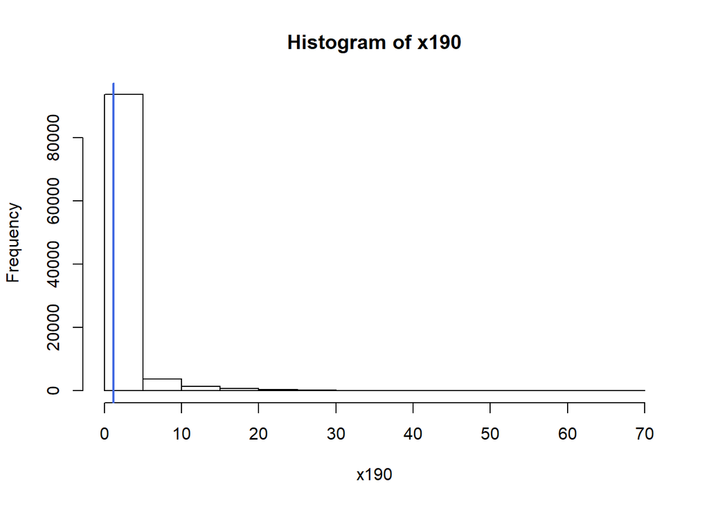

```r
##Now visualize the statistics
##Histogram

hist(data$x190,
    main = "Histogram of x190",
    xlab = "x190")
abline(v =mean(data$x190, na.rm = TRUE),col = "royalblue",
lwd = 2)
```

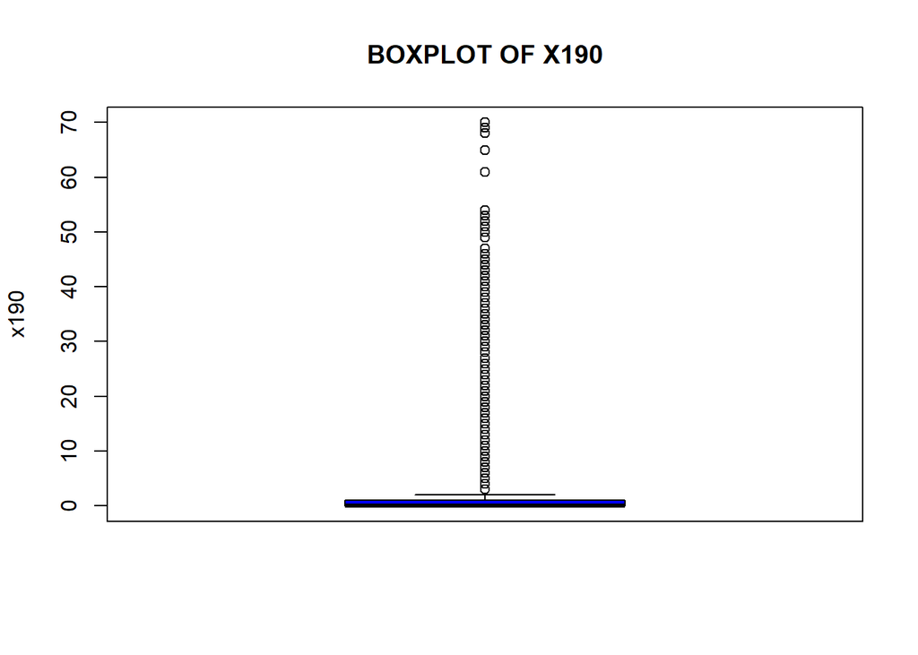

```r
##Boxplot
boxplot(data$x190,
       main = toupper("Boxplot of x190"),
       ylab = "x190",
       col = "blue")
```

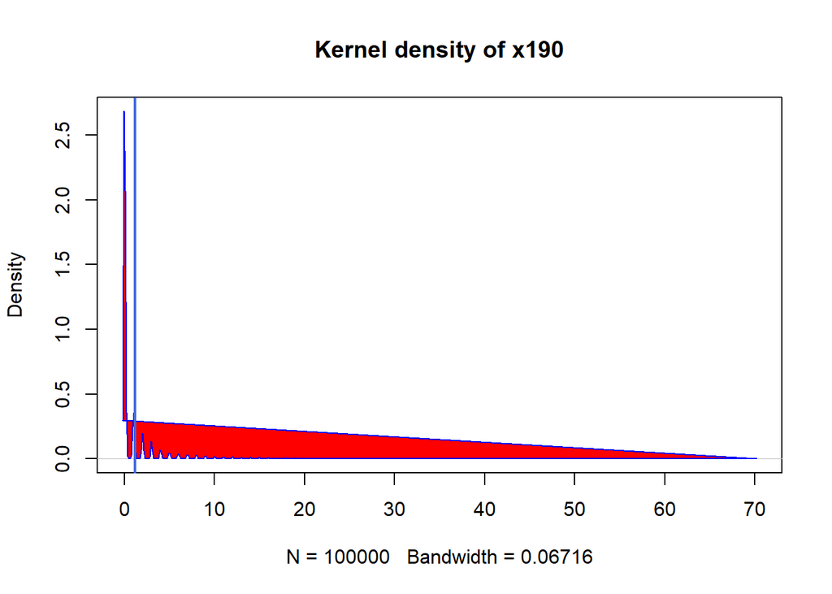

```r
##Density Plot
d <- density(data$x190, na.rm = TRUE)
plot(d, main = "Kernel density of x190")
polygon(d, col = "red", border = "blue")
abline(v =mean(data$x190, na.rm = TRUE),col = "royalblue",
lwd = 2)
```

## Obervation ## From the above graphs and stats i observed that 87% are below 2 and 93% are below 5

## There is positive skewness in the data. There are no missing values. This variable have descrete values.

## Variable 191

```r
head(data$x191)
```

```
## [1] 0 0 0 7 2 9
```

```r
## Summary of the data
summary(data$x191)
```

```
##    Min. 1st Qu.  Median    Mean 3rd Qu.    Max.
##   0.000   0.000   0.000   1.438   1.000  90.000
```

##Here we found that mean and median are not pretty close and we can say that the distribution of the variable is not approximately normal

##Missing Values: ##There are no missing values

##Description of the data

```r
#install.packages("psych")

describe(data$x191)
```

```
##    vars     n mean   sd median trimmed mad min max range skew kurtosis
## X1    1 1e+05 1.44 4.04      0    0.45   0   0  90    90 5.43    43.64
##      se
## X1 0.01
```

## Here the kurtosis is very high positive hence there is large data in tail

```r
table(data$x191)
```

```
##
##     0     1     2     3     4     5     6     7     8     9    10    11
## 70192 10158  4946  3151  2147  1591  1235   968   819   651   586   429
##    12    13    14    15    16    17    18    19    20    21    22    23
##   391   357   283   243   227   200   189   147   144   110   109    83
##    24    25    26    27    28    29    30    31    32    33    34    35
##    74    54    54    60    44    40    29    39    28    22    23    21
##    36    37    38    39    40    41    42    43    44    45    46    47
##     9    11     7    15    10     6    12     7     7     4     7     5
##    48    49    50    51    52    53    54    55    56    57    59    60
##     5     8     4     5     8     2     1     3     2     1     3     3
##    61    62    63    64    65    69    70    81    90
##     2     1     2     1     1     1     1     1     1
```

```r
str(data$x191)
```

```
##  int [1:100000] 0 0 0 7 2 9 0 1 0 10 ...
```

```r
class(data$x191)
```

```
## [1] "integer"
```

## here the all values in integer

```r
##Total number of values excluding NA
NROW(data[which(data$x191<=2),])
```

```
## [1] 85296
```

##i.e;., 85%

```r
NROW(data[which(data$x191<=5),])
```

```
## [1] 92185
```

##i.e;.,92%

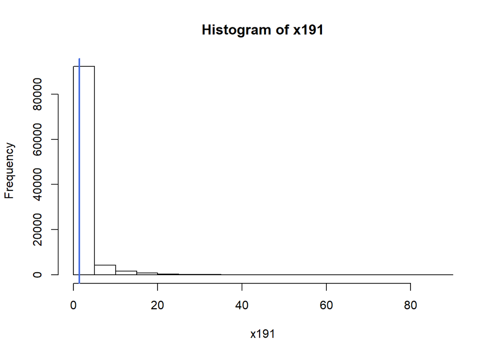

```r
##Now visualize the statistics
##Histogram

hist(data$x191,
    main = "Histogram of x191",
    xlab = "x191")
abline(v =mean(data$x191, na.rm = TRUE),col = "royalblue",
lwd = 2)
```

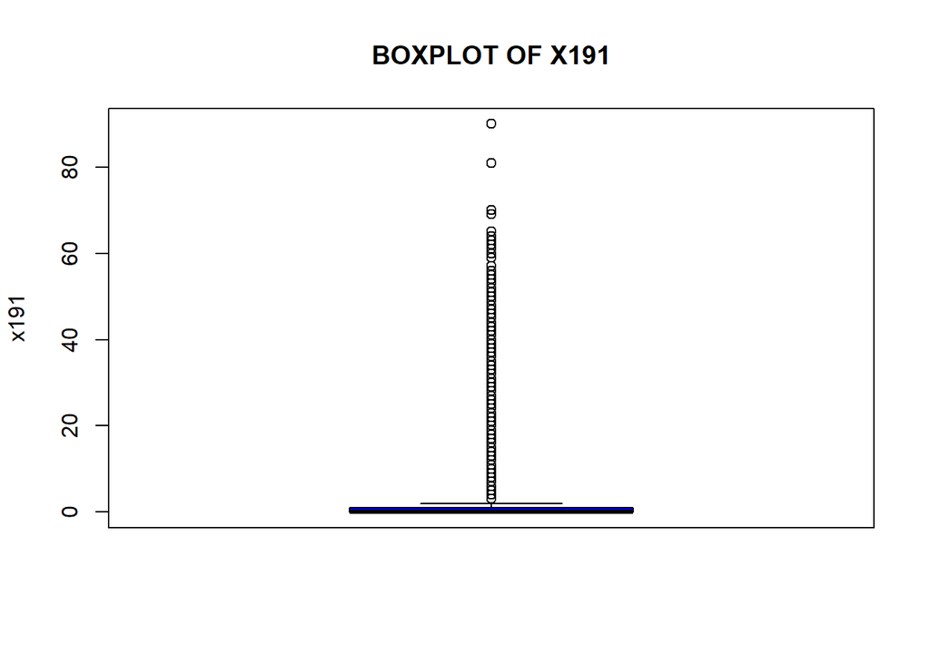

```r
##Boxplot
boxplot(data$x191,
       main = toupper("Boxplot of x191"),
       ylab = "x191",
       col = "blue")
```

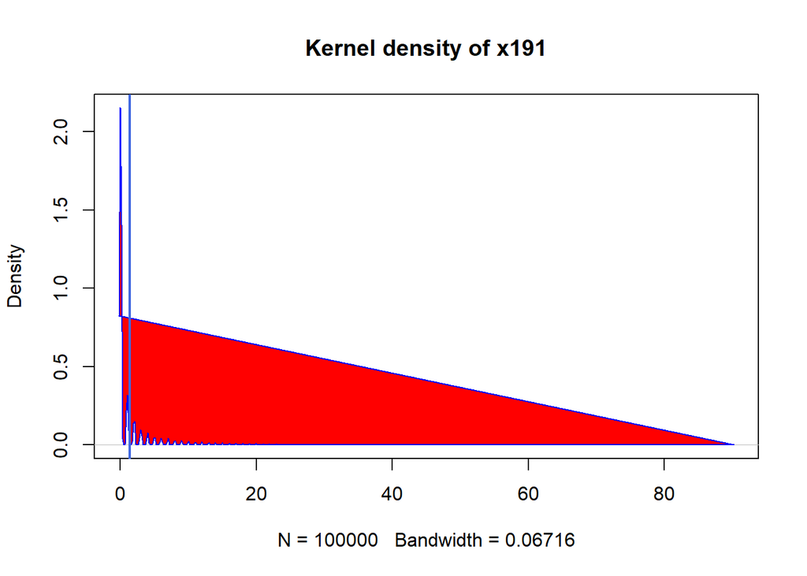

```r
##Density Plot
d <- density(data$x191, na.rm = TRUE)
plot(d, main = "Kernel density of x191")
polygon(d, col = "red", border = "blue")
abline(v =mean(data$x191, na.rm = TRUE),col = "royalblue",
lwd = 2)
```

## Obervation ## From the above graphs and stats i observed that 85% are below 2 and 92% are below 5

## There is positive skewness in the data. There are no missing values. This variable have descrete values.